# Steelhead Overshoot Update

2/10/2022

## Model setup

## Modeling overview

- Data still John Day River wild Steelhead, 2005-2015
- MLE form, implemented in optim()
- **Bayesian form, implemented in JAGS**

## Model setup

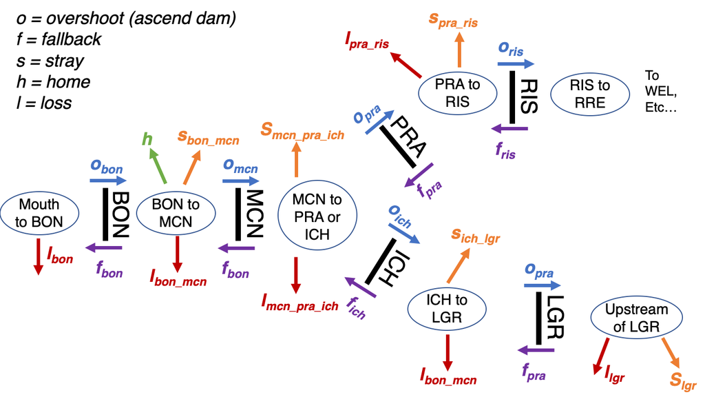

## Constraining movement probablities in each state to sum to 1

Two options:

1. Dirichlet prior (e.g., Waterhouse et al. 2020)

   ```r
   p <- 1 - q - r
   c(p, q, r) ~ ddirch(c(1, 1, 1))
   ```

2. Additive log-ratio (what I chose to implement):
- Used to transform (redefine) parameters that lie on the interval [0,1] to the interval [-Inf, Inf]
- Choose one parameter to serve as reference (denominator)

## Additive log-ratio: Example

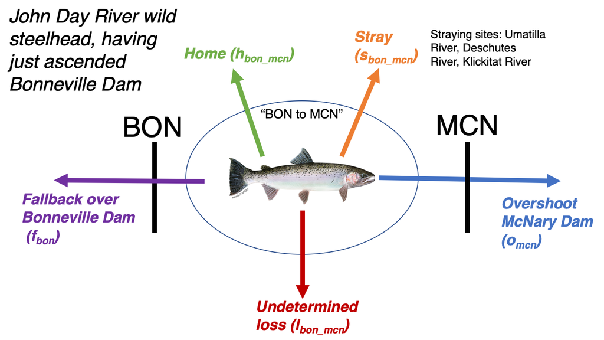

## Additive log-ratio: Example

\[ \begin{aligned} \small a_{2} = log(o_{mcn}/l_{bon\_mcn}) \\ \small b_{2} = log(s_{bon\_mcn}/l_{bon\_mcn}) \\ \small c_{2} = log(h_{bon\_mcn}/l_{bon\_mcn}) \\ \small d_{2} = log(f_{bon}/l_{bon\_mcn}) \\ \end{aligned} \]

\[ \begin{aligned} \small o_{mcn}= \exp(a_{2})/(1 + \exp(a_{2}) + \exp(b_{2}) + \exp(c_{2}) + \exp(d_{2})) \\ \small s_{bon\_mcn} = \exp(b_{2})/(1 + \exp(a_{2}) + \exp(b_{2}) + \exp(c_{2}) + \exp(d_{2})) \\ \small h_{bon\_mcn} = \exp(c_{2})/(1 + \exp(a_{2}) + \exp(b_{2}) + \exp(c_{2}) + \exp(d_{2})) \\ \small f_{bon} = \exp(d_{2})/(1 + \exp(a_{2}) + \exp(b_{2}) + \exp(c_{2}) + \exp(d_{2})) \\ \small l_{bon\_mcn} = 1/(1 + \exp(a_{2}) + \exp(b_{2}) + \exp(c_{2}) + \exp(d_{2})) \end{aligned} \]

## Priors

- Vague priors - normal with precision of 0.01 (equals SD of 10)

```r
a2 ~ dnorm(0, 0.01)
b2 ~ dnorm(0, 0.01)
c2 ~ dnorm(0, 0.01)
d2 ~ dnorm(0, 0.01)
```

- All parameters received these priors
- Currently 14 states in the model, so we have a1 - a14, and b, c, and/or d for the states that have more than two possible movements

## Multinomial likelihood

- Get a vector of probabilities *p* with length *K*, where *K* is the number of unique observed detection histories
- In this dataset, *K* = 169 (169 unique detection histories)
- Example:

\[ \begin{aligned} n_{7} = f_{bon} * o_{bon} * f_{bon} * o_{bon} * h_{bon\_mcn} * l_{nat\_trib} \\ p[7] = n_{7} \end{aligned} \]

## Evaluate multinomial likelihood

```r
p <- c(n1, n2, n3, ... n169)

# Evaluate counts, where y are the counts of
# the number of times each of the unique detection
# histories was observed

# 2121 are the number of fish
y[1:N] ~ dmulti(p[1:N], 2121)
```

- 36 parameters monitored

## Example plots

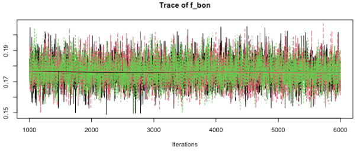

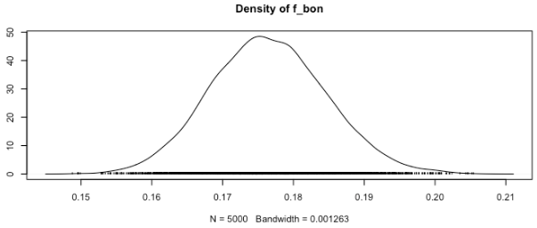

## Example model outputs

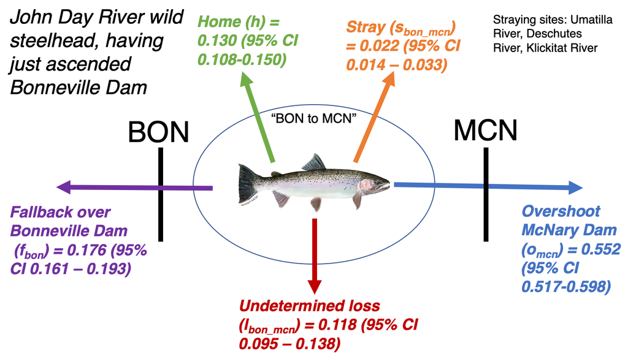

## Next steps

## Expanding dataset

- 14 (?) natal tributaries
- 2005 onwards
- Would have to build a new model for each new arrangement of operational PIT tag arrays - i.e., would have to build a new model for 2018 onwards, when the John Day adult fishway PIT tag detectors came online

## Adding complexity (via covariates, or different parameters)

1. Run year
2. Natal origin
3. Temperature
4. Spill
5. Juvenile history
6. Harvest (loss parameter?) - use WDFW data, summarize by river reach/state to align with model
7. Memory (overshoot?)

## Detection probability

- Implicit movements could be considered not detected
- For example, an individual with consecutive detections in the McNary adult fishways: \[ o_{mcn} * p_{o_{mcn}} * f_{mcn} * (1 - p_{f_{mcn}}) * o_{mcn} * p_{o_{mcn}} \] Would this help us estimate detection probabilities and thus unobserved fallback?

## Informative priors

- What are sources of information for priors?